# Prosper Loan Data Exploration

## by *Xinqi Lin*

- Introduction
- Data Wrangling, Assesing, & Cleaning
- Univarite Exploration
- Bivarite Exploration
- Multivarite Exploration
- Conclusions

## Introduction

In this project, I will explore a dataset of Prosper Loan data, which contains 113,937 rows and 81 columns. I will pick some of the variables that are related to Default to analyze. I will first do some data wrangling and cleaning, and then move on to EDA using different types of charts to explore relationships between/among variables, and hopefully find out which variables can best predict the Default.

## Data Wrangling, Assesing, & Cleaning

### Data Wrangling

```python
# import all packages and set plots to be embedded inline
import numpy as np
import pandas as pd
import matplotlib.pyplot as plt
import seaborn as sb
%matplotlib inline
import warnings
warnings.filterwarnings('ignore')
pd.set_option('display.max_columns', None)
```

```python
# Load the datasets and take a look at the first few rows.
loan = pd.read_csv("prosperLoanData.csv")
print(loan.head(5))
```

```
                ListingKey  ListingNumber            ListingCreationDate  \
0  1021339766868145413AB3B         193129  2007-08-26 19:09:29.263000000
1  10273602499503308B223C1        1209647  2014-02-27 08:28:07.900000000
2  0EE9337825851032864889A          81716  2007-01-05 15:00:47.090000000
3  0EF5356002482715299901A         658116  2012-10-22 11:02:35.010000000
4  0F023589499656230C5E3E2         909464  2013-09-14 18:38:39.097000000

  CreditGrade  Term LoanStatus           ClosedDate  BorrowerAPR  \
0           C    36  Completed  2009-08-14 00:00:00      0.16516
1         NaN    36    Current                  NaN      0.12016
2          HR    36  Completed  2009-12-17 00:00:00      0.28269
3         NaN    36    Current                  NaN      0.12528
4         NaN    36    Current                  NaN      0.24614

   BorrowerRate  LenderYield  EstimatedEffectiveYield  EstimatedLoss  \
```

[output cut: 173 more lines]

```python
# Overview of the dataset.
print(loan.shape)
print(loan.info())
# descriptive statistics for numeric variables
print(loan.describe())
```

```
(113937, 81)
<class 'pandas.core.frame.DataFrame'>
RangeIndex: 113937 entries, 0 to 113936
Data columns (total 81 columns):
 #   Column                               Non-Null Count   Dtype
---  ------                               --------------   -----
 0   ListingKey                           113937 non-null  object
 1   ListingNumber                        113937 non-null  int64
 2   ListingCreationDate                  113937 non-null  object
 3   CreditGrade                          28953 non-null   object
 4   Term                                 113937 non-null  int64
 5   LoanStatus                           113937 non-null  object
 6   ClosedDate                           55089 non-null   object
 7   BorrowerAPR                          113912 non-null  float64
 8   BorrowerRate                         113937 non-null  float64
 9   LenderYield                          113937 non-null  float64
 10  EstimatedEffectiveYield              84853 non-null   float64
 11  EstimatedLoss                        84853 non-null   float64
 12  EstimatedReturn                      84853 non-null   float64
 13  ProsperRating (numeric)              84853 non-null   float64
 14  ProsperRating (Alpha)                84853 non-null   object
 15  ProsperScore                         84853 non-null   float64
 16  ListingCategory (numeric)            113937 non-null  int64
 17  BorrowerState                        108422 non-null  object
 18  Occupation                           110349 non-null  object
 19  EmploymentStatus                     111682 non-null  object
 20  EmploymentStatusDuration             106312 non-null  float64
 21  IsBorrowerHomeowner                  113937 non-null  bool
 22  CurrentlyInGroup                     113937 non-null  bool
 23  GroupKey                             13341 non-null   object
 24  DateCreditPulled                     113937 non-null  object
 25  CreditScoreRangeLower                113346 non-null  float64
 26  CreditScoreRangeUpper                113346 non-null  float64
 27  FirstRecordedCreditLine              113240 non-null  object
 28  CurrentCreditLines                   106333 non-null  float64
 29  OpenCreditLines                      106333 non-null  float64
 30  TotalCreditLinespast7years           113240 non-null  float64
 31  OpenRevolvingAccounts                113937 non-null  int64
 32  OpenRevolvingMonthlyPayment          113937 non-null  float64
 33  InquiriesLast6Months                 113240 non-null  float64
```

[output cut: 264 more lines]

```
min           0.000000                    0.000000
25%           0.000000                    0.000000
50%           0.000000                    0.000000
75%           0.000000                    0.000000
max          39.000000                   33.000000

       InvestmentFromFriendsAmount      Investors
count                113937.000000  113937.000000
mean                     16.550751      80.475228
std                     294.545422     103.239020
min                       0.000000       1.000000
25%                       0.000000       2.000000
50%                       0.000000      44.000000
75%                       0.000000     115.000000
max                   25000.000000    1189.000000
```

```python
loan[loan.duplicated()]
# There's no duplicated rows.
```

|  | ListingKey | ListingNumber | ListingCreationDate | CreditGrade | Term | LoanStatus | ClosedDate | BorrowerAPR | BorrowerRate | LenderYield | EstimatedEffectiveYield | EstimatedLoss | EstimatedReturn | ProsperRating (numeric) | ProsperRating (Alpha) | ProsperScore | ListingCategory (numeric) | BorrowerState | Occupation | EmploymentStatus | EmploymentStatusDuration | IsBorrowerHomeowner | CurrentlyInGroup | GroupKey | DateCreditPulled | CreditScoreRangeLower | CreditScoreRangeUpper | FirstRecordedCreditLine | CurrentCreditLines | … |
| --- | --- | --- | --- | --- | --- | --- | --- | --- | --- | --- | --- | --- | --- | --- | --- | --- | --- | --- | --- | --- | --- | --- | --- | --- | --- | --- | --- | --- | --- | --- |

#### What is the structure of your dataset?

> There are 113,937 listings in the dataset with 81 features. Most variables are numeric, some are categorical, boolean and date. Variables like ProsperRating (Alpha) and IncomeRange can be ordered factor variables with the following levels.

> ProsperRating (Alpha): HR, E, D, C, B, A, AA (worst to best)

> IncomeRange: Not employed, \$0, \\$1-\$24,999, \\$25,000-\$49,999, \\$50,000-\$74,999, \\$75,000-\$99,999, \\$100,000+

> Some of the variables have a lot of null values, such as variables prosperrating and prosperscore, which I'll need to deal with later.

> Some variables are not of much use, such as listingkey, listingnumber, of other identifiers. These columns I will remove later.

#### What is/are the main feature(s) of interest in your dataset?

> I'm most interested in figuring out what features are best for predicting whether a loan would default or not, which is the LoanStatus variable.

#### What features in the dataset do you think will help support your investigation into your feature(s) of interest?

> I expect that variables related to borrowers' personal situation would have effect on default, such as EmploymentStatus, CreditScoreRangeLower/Upper, DelinquenciesLast7Years, IncomeRange, etc. Because a borrower's financial status will have huge effect on their ability to pay loans. There are so many variables to explore in this dataset, maybe I can do some feature engineering as well.

### Data Assessing and Cleaning

> Now it's time for some cleaning job. I will drop columns that I immediately know I won't need, and then deal with categorical variables first. After that, I will deal with float and int variables based on the order.

```python
loan_clean = loan.copy()
```

```python
# I will change the column names to lowercase and replace space with underscore for convenience.
loan_clean.columns = map(str.lower, loan_clean.columns)
loan_clean.columns = loan_clean.columns.str.replace(' ', '_')
```

```python
# Remove columns I absolutely don't need for my analysis.
loan_clean.drop(columns = ['listingkey', 'listingnumber', 'groupkey', 'loankey', 'loannumber', 'memberkey', 'closeddate'], inplace = True)
```

```python
# Deal with categorical variables' null values.
categorical_columns = loan_clean.select_dtypes(include = 'object').columns
loan_clean[categorical_columns] = loan_clean[categorical_columns].fillna('unknown')
loan_clean.select_dtypes(include = 'object').isnull().sum()
```

```
listingcreationdate        0
creditgrade                0
loanstatus                 0
prosperrating_(alpha)      0
borrowerstate              0
occupation                 0
employmentstatus           0
datecreditpulled           0
firstrecordedcreditline    0
incomerange                0
loanoriginationdate        0
loanoriginationquarter     0
dtype: int64
```

```python
# Since APR = Interest rate + fee, and borrowrate column does not have null values, so I'll remove borrowerapr column
loan_clean.drop(columns = 'borrowerapr', inplace = True)
```

```python
# Estimatedeffectiveyield, estimatedloss & estimatedreturn all have null values, and they are connected borrowerrate as well.
# And since I won't use these variables for my analysis, I'll drop them now.
loan_clean.drop(columns = ['estimatedeffectiveyield', 'estimatedloss', 'estimatedreturn'], inplace = True)
```

```python
# For variables prosperrating_(numeric), prosperrating_(alpha), and prosperscore,
# I will choose proserrating_(alpha) here and drop the other two because they have null values.
loan_clean.drop(columns = ['prosperrating_(numeric)', 'prosperscore'], inplace = True)
```

```python
# Variables employmentstatusduration, creditscorerangelower, creditscorerangeupper, currentcreditlines,
# opencreditlines, totalcreditlinespast7years, currentdelinquencies, amountdelinquent, delinquencieslast7years,
# they all have some small amount of null values, but I don't want to remove those columns because they might prove to be
# useful in my analysis, and I don't want to fill in some values based on my judgement, so I'll drop those null rows.
loan_clean.dropna(subset = ['employmentstatusduration', 'creditscorerangelower', 'creditscorerangeupper', \
                            'currentcreditlines', 'opencreditlines', 'totalcreditlinespast7years', 'currentdelinquencies', \
                            'amountdelinquent', 'delinquencieslast7years'], inplace = True)
```

```python
# Variable debttoincomeratio is one important variable in this dataset, because if the borrower's debt-income ratio is too high,
# they won't have enough cashflow to return the debt, which could very likely lead to default.
# But there're many null values in that column, let's see what's going on.
loan_clean[loan_clean['debttoincomeratio'].isnull()][:5]
```

|  | listingcreationdate | creditgrade | term | loanstatus | borrowerrate | lenderyield | prosperrating_(alpha) | listingcategory_(numeric) | borrowerstate | occupation | employmentstatus | employmentstatusduration | isborrowerhomeowner | currentlyingroup | datecreditpulled | creditscorerangelower | creditscorerangeupper | firstrecordedcreditline | currentcreditlines | opencreditlines | totalcreditlinespast7years | openrevolvingaccounts | openrevolvingmonthlypayment | inquirieslast6months | totalinquiries | currentdelinquencies | amountdelinquent | delinquencieslast7years | publicrecordslast10years | … |
| --- | --- | --- | --- | --- | --- | --- | --- | --- | --- | --- | --- | --- | --- | --- | --- | --- | --- | --- | --- | --- | --- | --- | --- | --- | --- | --- | --- | --- | --- | --- |
| 40 | 2014-01-27 12:02:57.523000000 | unknown | 60 | Current | 0.1725 | 0.1625 | C | 1 | WA | Other | Self-employed | 276.0 | False | False | 2014-01-25 10:47:25 | 680.0 | 699.0 | 1985-12-20 00:00:00 | 10.0 | 9.0 | 28.0 | 10 | 1233.0 | 0.0 | 2.0 | 0.0 | 0.0 | 0.0 | 0.0 | … |
| 69 | 2014-01-25 12:07:54.537000000 | unknown | 60 | Current | 0.1139 | 0.1039 | A | 1 | IL | Investor | Self-employed | 12.0 | True | True | 2014-01-25 11:51:41 | 700.0 | 719.0 | 1995-08-01 00:00:00 | 5.0 | 5.0 | 21.0 | 3 | 373.0 | 0.0 | 2.0 | 0.0 | 0.0 | 0.0 | 0.0 | … |
| 78 | 2008-06-29 23:23:40.157000000 | A | 36 | Chargedoff | 0.1700 | 0.1600 | unknown | 3 | CA | Realtor | Full-time | 68.0 | True | False | 2008-06-29 23:13:04.860000000 | 720.0 | 739.0 | 1995-11-29 00:00:00 | 14.0 | 14.0 | 26.0 | 9 | 962.0 | 4.0 | 11.0 | 0.0 | 0.0 | 0.0 | 0.0 | … |
| 100 | 2013-01-25 11:48:26.040000000 | unknown | 36 | Chargedoff | 0.3134 | 0.3034 | HR | 13 | CA | Other | Not employed | 12.0 | False | False | 2013-01-11 12:10:13 | 720.0 | 739.0 | 2000-09-10 00:00:00 | 3.0 | 3.0 | 10.0 | 3 | 56.0 | 0.0 | 2.0 | 0.0 | 0.0 | 0.0 | 0.0 | … |
| 103 | 2012-04-17 11:58:52.270000000 | unknown | 36 | Chargedoff | 0.2287 | 0.2187 | D | 3 | CO | Truck Driver | Self-employed | 29.0 | True | False | 2012-04-17 11:58:46 | 680.0 | 699.0 | 1993-10-26 00:00:00 | 9.0 | 7.0 | 21.0 | 1 | 699.0 | 0.0 | 0.0 | 0.0 | 0.0 | 0.0 | 0.0 | … |

```python
# I found some useful variables here.
loan_clean.loc[loan_clean['debttoincomeratio'].isnull(), ['debttoincomeratio', 'monthlyloanpayment', 'statedmonthlyincome']]
```

|  | debttoincomeratio | monthlyloanpayment | statedmonthlyincome |
| --- | --- | --- | --- |
| 40 | NaN | 374.81 | 12750.000000 |
| 69 | NaN | 197.44 | 2700.000000 |
| 78 | NaN | 171.13 | 0.000000 |
| 100 | NaN | 172.76 | 0.000000 |
| 103 | NaN | 579.63 | 5000.000000 |
| ... | ... | ... | ... |
| 113893 | NaN | 383.27 | 5000.000000 |
| 113894 | NaN | 30.88 | 7500.000000 |
| 113899 | NaN | 154.27 | 4166.666667 |
| 113903 | NaN | 365.17 | 3833.333333 |
| 113908 | NaN | 327.49 | 2833.333333 |

8404 rows × 3 columns

```python
loan_clean.loc[loan_clean['debttoincomeratio'].isnull(), ['debttoincomeratio', 'monthlyloanpayment', 'statedmonthlyincome']].isnull().sum()
```

```
debttoincomeratio      8404
monthlyloanpayment        0
statedmonthlyincome       0
dtype: int64
```

```python
# So it seems like none of these rows have null monthlyloanpayment and statedmonthlyincome value.
# Let's just calculate debt-income ratio using these two columns then.
loan_clean['debttoincomeratio'].fillna(loan_clean['monthlyloanpayment'] / loan_clean['statedmonthlyincome'], inplace = True)
```

```python
# But now we have inf debtincomeratio, which is caused by 0 stated monthly income.
loan_clean[loan_clean['debttoincomeratio'] == np.inf]['debttoincomeratio'].value_counts()
```

```
inf    1327
Name: debttoincomeratio, dtype: int64
```

```python
# So now I will add 1 to statedmonthlyincome to calculate debttoincomeratio when statedmonthlyincome equals 0.
loan_clean['debttoincomeratio'].replace(np.inf, np.nan, inplace = True)
loan_clean['debttoincomeratio'].fillna(loan_clean['monthlyloanpayment'] / (loan_clean['statedmonthlyincome'] + 1), inplace = True)
```

```python
# For variables totalprosperloans, totalprosperpaymentsbilled, ontimeprosperpayments, prosperpaymentslessthanonemonthlate,
# prosperpaymentsonemonthpluslate, prosperprincipalborrowed, and prosperprincipaloutstanding, we know from the dictionary that
# these values will be null if the borrower had no prior loans. So I'll change null values to 0.
columns = ['totalprosperloans', 'totalprosperpaymentsbilled', 'ontimeprosperpayments', 'prosperpaymentslessthanonemonthlate',\
            'prosperpaymentsonemonthpluslate', 'prosperprincipalborrowed', 'prosperprincipaloutstanding']
for col in columns:
    loan_clean[col].fillna(0, inplace = True)
```

```python
# I'll drop scorexchangeattimeoflisting, LP_, loanfirstdefaultedcyclenumber, and recommendations columns too because I will not use them.
loan_clean.drop(columns = ['scorexchangeattimeoflisting', 'loanfirstdefaultedcyclenumber', 'lp_customerpayments',\
                          'lp_customerprincipalpayments', 'lp_interestandfees', 'lp_servicefees', 'lp_collectionfees',\
                          'lp_grossprincipalloss', 'lp_netprincipalloss', 'lp_nonprincipalrecoverypayments'], inplace = True)
```

```python
loan_clean.info()
```

```
<class 'pandas.core.frame.DataFrame'>
Int64Index: 106290 entries, 0 to 113936
Data columns (total 58 columns):
 #   Column                               Non-Null Count   Dtype
---  ------                               --------------   -----
 0   listingcreationdate                  106290 non-null  object
 1   creditgrade                          106290 non-null  object
 2   term                                 106290 non-null  int64
 3   loanstatus                           106290 non-null  object
 4   borrowerrate                         106290 non-null  float64
 5   lenderyield                          106290 non-null  float64
 6   prosperrating_(alpha)                106290 non-null  object
 7   listingcategory_(numeric)            106290 non-null  int64
 8   borrowerstate                        106290 non-null  object
 9   occupation                           106290 non-null  object
```

[output cut: 50 more lines]

## Univariate Exploration

> I want to start by looking at the main variable of interest - loanstatus.

```python
loan_clean.loanstatus.value_counts()
```

```
Current                   56566
Completed                 33530
Chargedoff                10632
Defaulted                  3289
Past Due (1-15 days)        806
Past Due (31-60 days)       363
Past Due (61-90 days)       313
Past Due (91-120 days)      304
Past Due (16-30 days)       265
FinalPaymentInProgress      205
Past Due (>120 days)         16
Cancelled                     1
Name: loanstatus, dtype: int64
```

```python
loan_analysis = loan_clean[loan_clean['loanstatus'].isin(['Completed', 'Chargedoff', 'Defaulted', 'Past Due (1-15 days)', \
                                                          'Past Due (31-60 days)', 'Past Due (61-90 days)', 'Past Due (91-120 days)'\
                                                         'Past Due (16-30 days)', 'Past Due (>120 days)'])]
```

```python
loan_analysis['default'] = np.where(loan_analysis['loanstatus'] == 'Completed', 0, 1)
```

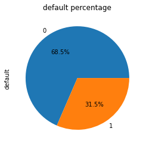

```python
loan_analysis['default'].value_counts().plot(kind = 'pie', autopct = '%1.1f%%');
plt.title('default percentage')
```

> Of the loans that are not in current status, around 68.5% of them were completed, and 31.5% were defualted.

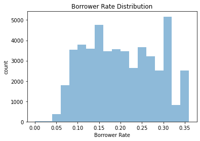

```python
# univariate plots of borrowerrate
base_color = sb.color_palette()[0]
bins = np.arange(0, loan_analysis['borrowerrate'].max() + 0.01, 0.02);
plt.hist(data = loan_analysis, x = 'borrowerrate', bins = bins, alpha = 0.5, color = base_color);
plt.title('Borrower Rate Distribution');
plt.xlabel('Borrower Rate');
plt.ylabel('count');
```

> The borrower rate has 2 spikes at 0.15 and 0.31, and most of the borrower rate lies between 0.07 and 0.30.

```python
# univariate plots of prosperrating_(alpha)
prosperrating_classes = ['unknown', 'HR', 'E', 'D', 'C', 'B', 'A', 'AA']
loan_analysis['prosperrating_(alpha)'] = pd.Categorical(loan_analysis['prosperrating_(alpha)'], categories = prosperrating_classes, ordered = True)
```

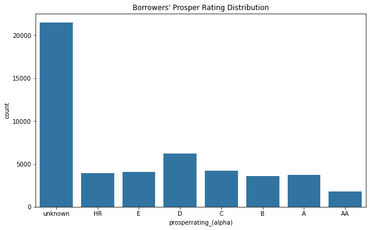

```python
plt.subplots(figsize = (10, 6))
sb.countplot(data = loan_analysis, x = 'prosperrating_(alpha)', color = base_color);
plt.title("Borrowers' Prosper Rating Distribution");
```

> There's too much unknown rows in the data, which I assume are from data before July 2009. I'll let go of this variable for now.

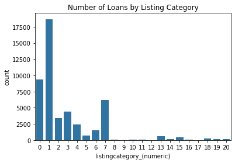

```python
# univariate plots of listingcategory_(numeric)
sb.countplot(data = loan_analysis, x = 'listingcategory_(numeric)', color = base_color);
plt.title('Number of Loans by Listing Category');
```

> Certain categories have more loans, I'll find out if there's a correlation between listing category and default rate later.

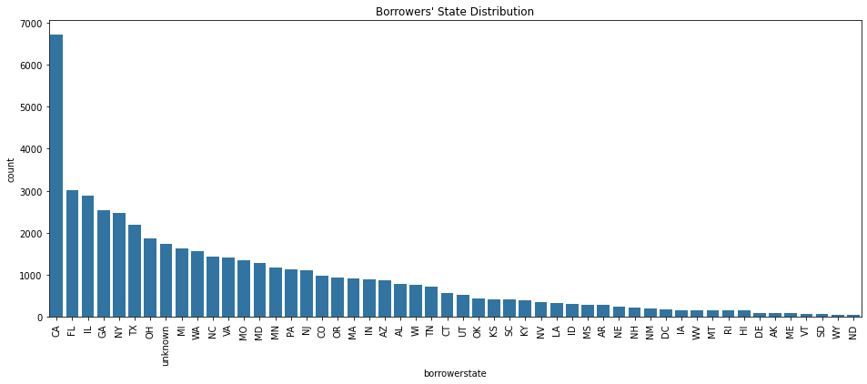

```python
# Now I'd like to see if location matters.
# univariate plots of borrowerstate
state_order = loan_analysis['borrowerstate'].value_counts().index
plt.subplots(figsize = (16, 6));
sb.countplot(data = loan_analysis, x = 'borrowerstate', color = base_color, order = state_order);
plt.xticks(rotation = 90);
plt.title("Borrowers' State Distribution");
```

> There are much more borrowers from California. Now I'm curious which state has the highest average default rate, which I'll address in the bivariate analysis.

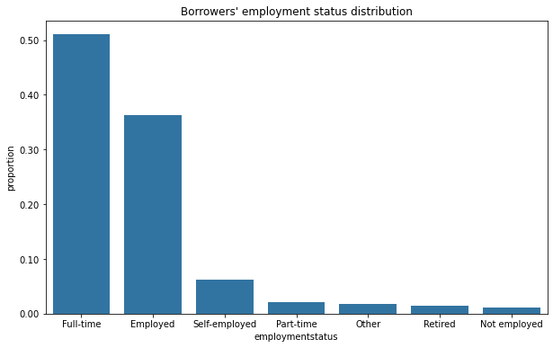

```python
# univariate plots of employmentstatus
type_counts = loan_analysis['employmentstatus'].value_counts()
type_order = type_counts.index
n_employment = loan_analysis['employmentstatus'].value_counts().sum()
max_type_count = type_counts[0]
max_prop = max_type_count / n_employment
tick_props = np.arange(0, max_prop, 0.1)
tick_names = ['{:0.2f}'.format(v) for v in tick_props]
plt.subplots(figsize = (10, 6))
base_color = sb.color_palette()[0]
sb.countplot(data = loan_analysis, x = 'employmentstatus', color = base_color, order = type_order);
plt.yticks(tick_props * n_employment, tick_names);
plt.ylabel('proportion');
plt.title("Borrowers' employment status distribution");
```

```python
loan_analysis['incomerange'].unique()
```

```
array(['$25,000-49,999', '$1-24,999', '$50,000-74,999', '$75,000-99,999',
       '$100,000+', 'Not employed', '$0', 'Not displayed'], dtype=object)
```

```python
# univariate plots of incomerange
income_classes = ['Not employed', 'Not displayed', '$0', '$1-24,999', '$25,000-49,999', '$50,000-74,999', '$75,000-99,999', '$100,000+']
loan_analysis['incomerange'] = pd.Categorical(loan_analysis['incomerange'], categories = income_classes, ordered = True)
```

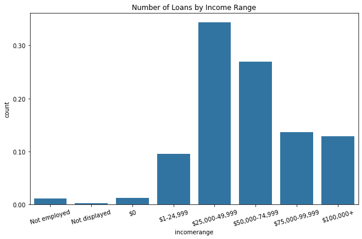

```python
income_counts = loan_analysis['incomerange'].value_counts()
n_income = loan_analysis['incomerange'].value_counts().sum()
max_income_count = income_counts[0]
max_prop_income = max_income_count / n_income
tick_props = np.arange(0, max_prop_income, 0.1)
tick_names = ['{:0.2f}'.format(v) for v in tick_props]
plt.subplots(figsize = (10, 6))
base_color = sb.color_palette()[0]
sb.countplot(data = loan_analysis, x = 'incomerange', color = base_color);
plt.yticks(tick_props * n_income, tick_names)
plt.xticks(rotation = 15);
plt.title('Number of Loans by Income Range');
```

> Also, most borrowers have income range \$25,000 - \\$$49,999.

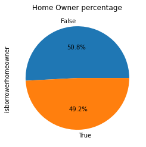

```python
# univariate plots of isborrowerhomeowner
loan_analysis['isborrowerhomeowner'].value_counts().plot(kind = 'pie', autopct = '%1.1f%%');
plt.title('Home Owner percentage');
```

> Around 50% of the borrowers are already home owners themselves, perhapes there's a correlation between being a home owner and default?

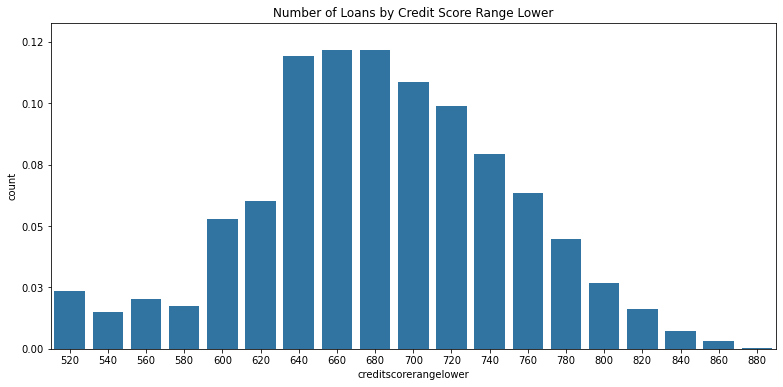

```python
# univariate plots of creditscorerangelower
credit_counts = loan_analysis['creditscorerangelower'].value_counts()
n_credit = loan_analysis['creditscorerangelower'].value_counts().sum()
max_credit_count = income_counts[0]
max_prop_credit = max_credit_count / n_credit
tick_props = np.arange(0, max_prop_credit, 0.025)
tick_names = ['{:0.2f}'.format(v) for v in tick_props]
loan_analysis['creditscorerangelower'] = loan_analysis['creditscorerangelower'].apply(int)
plt.subplots(figsize = (13, 6))
sb.countplot(data = loan_analysis, x = 'creditscorerangelower', color = base_color)
plt.yticks(tick_props * n_income, tick_names);
plt.title('Number of Loans by Credit Score Range Lower')
plt.ylim(0, 6500);
```

> Credit score range lower concentrates on 640 - 720, not many borrowers had credit score lower than 580.

> Later, I'll want to see if there's correlation between employment/credit score and default.

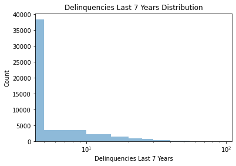

```python
# univariate plots of delinquencieslast7years
bins = np.arange(0, loan_analysis['delinquencieslast7years'].max() + 1, 5);
plt.hist(data = loan_analysis, x = 'delinquencieslast7years', bins = bins, alpha = 0.5);
plt.xscale('log');
plt.title('Delinquencies Last 7 Years Distribution');
plt.xlabel('Delinquencies Last 7 Years');
plt.ylabel('Count');
```

> Total delinquencies last 7 years looks highly skewed. So I'll do some transformation for this variable.

```python
np.log10(loan_analysis['delinquencieslast7years'].describe())
```

```
count    4.689744
mean     0.617525
std      1.001410
min          -inf
25%          -inf
50%          -inf
75%      0.477121
max      1.995635
Name: delinquencieslast7years, dtype: float64
```

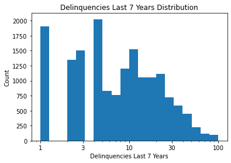

```python
# Most of the borrowers had no delinquencies in the last 7 years, I'll only plot rows with deliquencies here.
bins = 10 ** np.arange(0, 2 + 0.1, 0.1)
ticks = [1, 3, 10, 30, 100]
labels = ['{}'.format(v) for v in ticks]
plt.hist(data = loan_analysis, x = 'delinquencieslast7years', bins = bins);
plt.xscale('log');
plt.xticks(ticks, labels);
plt.title('Delinquencies Last 7 Years Distribution');
plt.xlabel('Delinquencies Last 7 Years');
plt.ylabel('Count');
```

> Total delinquencies in the last 7 years can go as high as 100 times, but most of them are under 30 times. I'll create a new boolean variable that indicates if a borrower had delinquency in the last 7 years or not, and use this boolean variable for my further analysis.

```python
loan_analysis['delinquent'] = np.where(loan_analysis['delinquencieslast7years'] == 0, 0, 1)
```

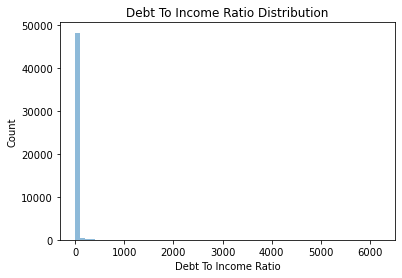

```python
# univariate plots of debttoincomeratio
bins = np.arange(0, loan_analysis['debttoincomeratio'].max() + 1, 100);
plt.hist(data = loan_analysis, x = 'debttoincomeratio', bins = bins, alpha = 0.5);
plt.title('Debt To Income Ratio Distribution');
plt.xlabel('Debt To Income Ratio');
plt.ylabel('Count');
```

```python
loan_analysis['debttoincomeratio'].describe()
```

```
count    48949.000000
mean         5.711041
std         57.857881
min          0.000000
25%          0.120000
50%          0.200000
75%          0.310000
max       6291.865167
Name: debttoincomeratio, dtype: float64
```

```python
np.log10(loan_analysis['debttoincomeratio'].describe())
```

```
count    4.689744
mean     0.756715
std      1.762363
min          -inf
25%     -0.920819
50%     -0.698970
75%     -0.508638
max      3.798779
Name: debttoincomeratio, dtype: float64
```

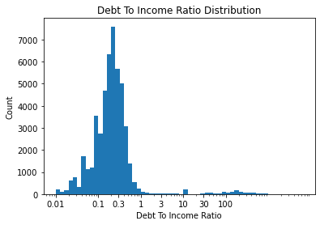

```python
# I'll only plot rows with debttoincomeratio > 0 here.
bins = 10 ** np.arange(-2, 3.8 + 0.1, 0.1)
ticks = [0.01, 0.1, 0.3, 1, 3, 10, 30, 100]
labels = ['{}'.format(v) for v in ticks]
plt.hist(data = loan_analysis, x = 'debttoincomeratio', bins = bins);
plt.xscale('log');
plt.xticks(ticks, labels);
plt.title('Debt To Income Ratio Distribution');
plt.xlabel('Debt To Income Ratio');
plt.ylabel('Count');
```

> Most of the borrowers have debt to income ratio in range (0, 1), some have the ratio even higher than 100. I'll look at the correlation between this ratio and default rate later.

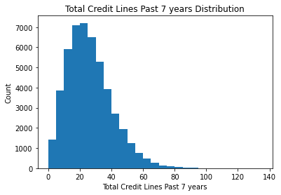

```python
# univariate plots of totalcreditlinespast7years
bins = np.arange(0, loan_analysis['totalcreditlinespast7years'].max() + 1, 5);
plt.hist(data = loan_analysis, x = 'totalcreditlinespast7years', bins = bins);
plt.title('Total Credit Lines Past 7 years Distribution');
plt.xlabel('Total Credit Lines Past 7 years');
plt.ylabel('Count');
```

> Seems kind of skewed, let's do some transformation as well.

```python
np.log(loan_analysis['totalcreditlinespast7years'].describe())
```

```
count    10.798534
mean      3.249056
std       2.658270
min       0.693147
25%       2.708050
50%       3.178054
75%       3.526361
max       4.912655
Name: totalcreditlinespast7years, dtype: float64
```

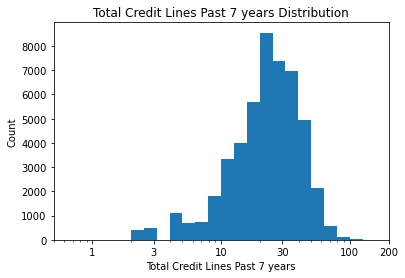

```python
bins = 10 ** np.arange(0, 4.9 + 0.1, 0.1)
ticks = [1, 3, 10, 30, 100, 200]
labels = ['{}'.format(v) for v in ticks]
plt.hist(data = loan_analysis, x = 'totalcreditlinespast7years', bins = bins);
plt.xscale('log');
plt.xticks(ticks, labels);
plt.xlim(0.5, 200);
plt.title('Total Credit Lines Past 7 years Distribution');
plt.xlabel('Total Credit Lines Past 7 years');
plt.ylabel('Count');
```

> Many of the borrowers have at least 10 to 40 credit lines. Is it the more the merrier?

## Bivariate Exploration

> Let's start by exploring borrowerrate and default rate.

#### Is default correlated with borrowerrate?

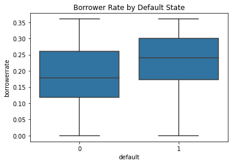

```python
sb.boxplot(data = loan_analysis, x = 'default', y = 'borrowerrate', color = base_color);
plt.title('Borrower Rate by Default State')
```

> Looks like in the default group, the borrowerrate is higher. What could be correlated with borrowerrate? Maybe income and credit score?

#### Is income correlated with borrower rate?

```
$25,000-49,999    16826
$50,000-74,999    13184
$75,000-99,999     6681
$100,000+          6299
$1-24,999          4668
$0                  607
Not employed        546
Not displayed       138
Name: incomerange, dtype: int64
```

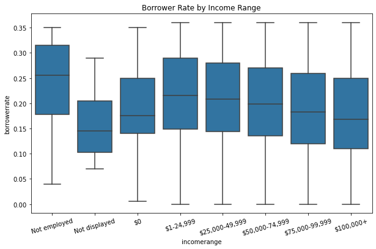

```python
plt.subplots(figsize = (10, 6));
sb.boxplot(data = loan_analysis, x = 'incomerange', y = 'borrowerrate', color = base_color);
plt.xticks(rotation = 15);
plt.title('Borrower Rate by Income Range');
print(income_counts)
```

#### Is credit score correlated with borrower rate?

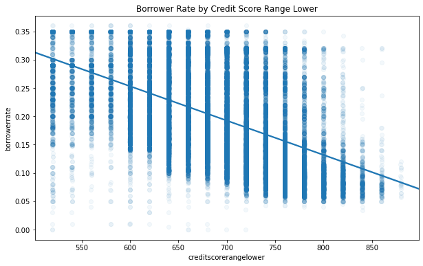

```python
plt.figure(figsize = (10, 6))
sb.regplot(data = loan_analysis, x = 'creditscorerangelower', y = 'borrowerrate', truncate = False, x_jitter = 0.3, scatter_kws={'alpha':1/20});
plt.xlabel('creditscorerangelower')
plt.ylabel('borrowerrate');
plt.title('Borrower Rate by Credit Score Range Lower');
```

> The borrowerrate does seem to be correlated with credit score! There is a negative correlation between these two variables.

#### Which income group has most defaults?

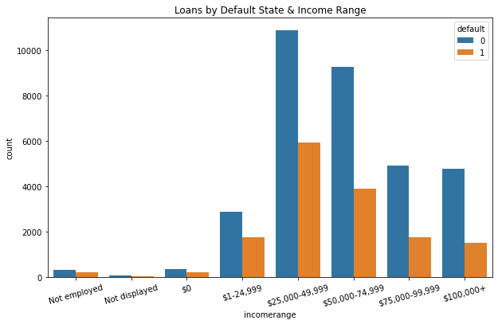

```python
# Let's look at correlation between incomerange and default too.
plt.subplots(figsize = (10, 6))
sb.countplot(data = loan_analysis, x = 'incomerange', hue = 'default');
plt.xticks(rotation = 15);
plt.title('Loans by Default State & Income Range');
```

> From previous analysis, we know there are more borrowers with income range \$25,000 - \\$49,999, and from the graph above, we can also know that more defaulted loans came from that range too. But does that group have the highest default rate? Let's calculate the default rate of each income range.

#### Which income group has the highest default rate?

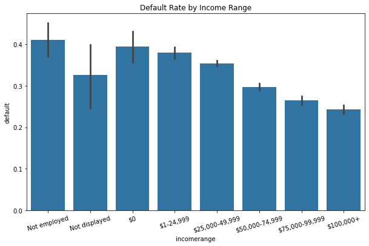

```python
plt.figure(figsize = (10, 6))
sb.barplot(data = loan_analysis, x = 'incomerange', y = 'default', color = base_color);
plt.xticks(rotation = 15);
plt.title('Default Rate by Income Range');
```

> Now, we know that the highest default rate did not come from income range \$25,000 - \\$49,999, it's actually come from `Not Employed` group and `$0` group, which kind of makes more sense now, because people that's not employed and not having income might lead to their financial crisis, which could increase the possibility of not being able to pay the loan. Even though \$0 group has lower borrowerrate, they still were more likely to be defaulted. But then, Not display group's average default rate is lower than \\$0 - \$49,999, which makes me wonder maybe that group actually has income.

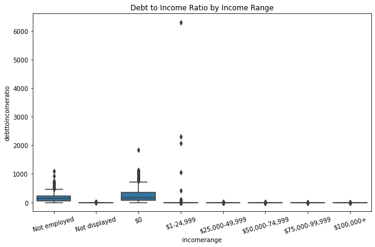

```python
plt.figure(figsize = (10, 6))
sb.boxplot(data = loan_analysis, x = 'incomerange', y = 'debttoincomeratio', color = base_color);
plt.xticks(rotation = 15);
plt.title('Debt to Income Ratio by Income Range');
```

> Group Not Employed and \$0 have much higher Debt to Income Ratio on average. But strangely, group \\$1 - \$24,999 has some pretty high outliers too. I will seperate these group in the following analysis.

#### do certain listing categories have higher default rate?

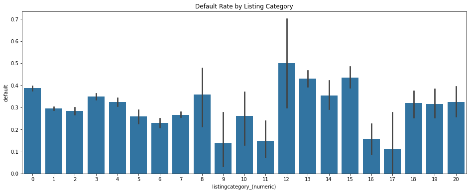

```python
plt.subplots(figsize = (16, 6))
sb.barplot(data = loan_analysis, x = 'listingcategory_(numeric)', y = 'default', color = base_color);
plt.title('Default Rate by Listing Category');
```

> Certain types of loans do have higher default rate on average.

#### Is each state's default rate different?

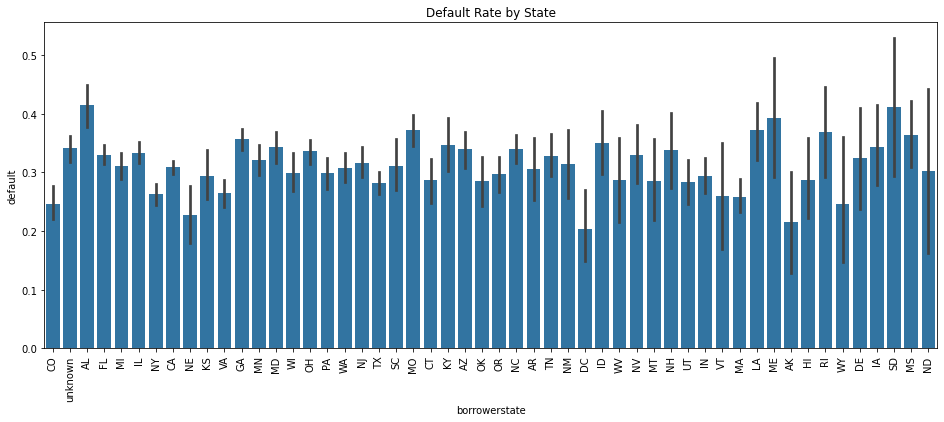

```python
plt.subplots(figsize = (16, 6))
sb.barplot(data = loan_analysis, x = 'borrowerstate', y = 'default', color = base_color);
plt.xticks(rotation = 90);
plt.title('Default Rate by State');
```

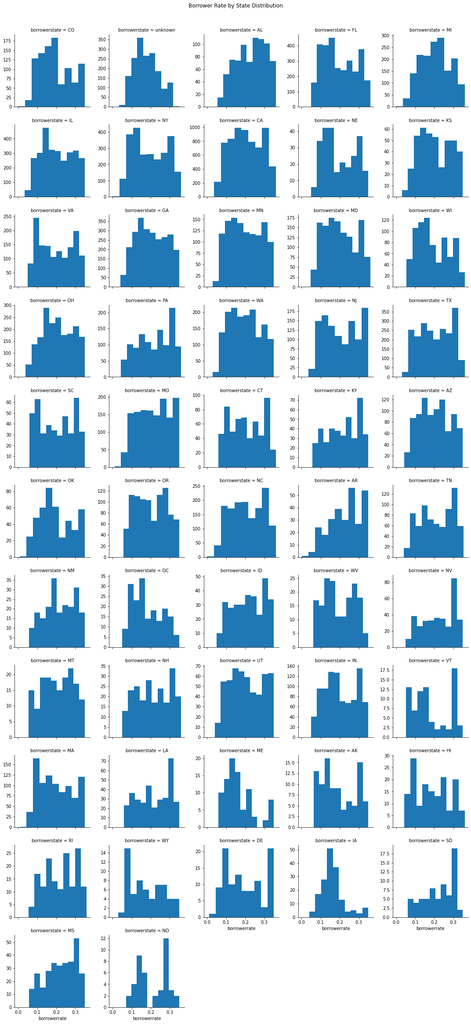

```python
g = sb.FacetGrid(data = loan_analysis, col = 'borrowerstate', col_wrap=5, sharey=False)
g.map(plt.hist, 'borrowerrate');
g.fig.subplots_adjust(top = 0.95);
g.fig.suptitle('Borrower Rate by State Distribution');
```

> There's some obvious differences among different states' default rates as well. For example, CO's average default rate is only at aroung 0.25, whereas AL's average default rate is at aroung 0.41. Each state's distribution of borrower rate vary too.

#### Is borrower being a homeowner correlated with default rate?

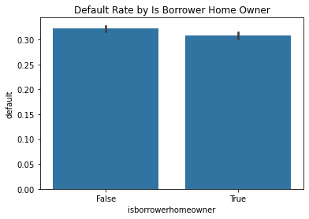

```python
sb.barplot(data = loan_analysis, x = 'isborrowerhomeowner', y = 'default', color = base_color);
plt.title('Default Rate by Is Borrower Home Owner');
```

> There's some difference, but I wouldn't say the difference seem significant.

#### Is there a correlation between credit score lower range and default rate?

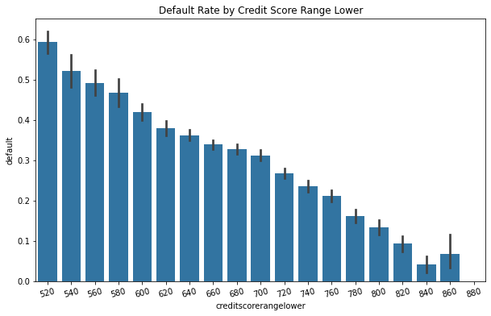

```python
plt.subplots(figsize = (10, 6))
sb.barplot(data = loan_analysis, x = 'creditscorerangelower', y = 'default', color = base_color);
plt.xticks(rotation = 15);
plt.title('Default Rate by Credit Score Range Lower');
```

> Wow, looks like there's a strong negative correlation between credit scroe lower range and default rate. However, credit score 860 looks a bit strange.

#### Is there a correlation between debttoincomeratio and default rate?

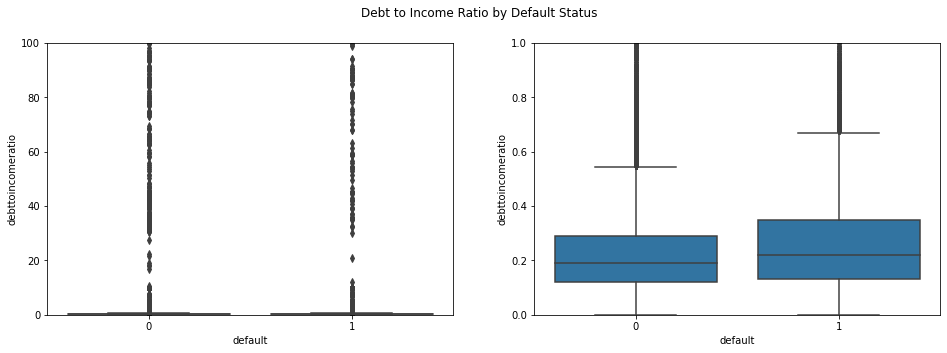

```python
fig = plt.figure(figsize = [16, 5])
plt.subplot(1, 2, 1)
ax1 = sb.boxplot(data = loan_analysis, x = 'default', y = 'debttoincomeratio', color = base_color);
plt.ylim(0, 100);
plt.subplot(1, 2, 2)
ax2 = sb.boxplot(data = loan_analysis, x = 'default', y = 'debttoincomeratio', color = base_color);
plt.ylim(0, 1);
fig.suptitle('Debt to Income Ratio by Default Status');
```

> From the left box plot, we cannot really tell the difference between 2 groups, because there are too many outliers. But if we only look at debttoincomeratio under 1, then we'll see that the default group has a higher range of debttoincomeratio than the non-default group.

#### Is number of credit lines correlated with default rate?

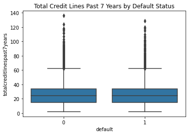

```python
sb.boxplot(data = loan_analysis, x = 'default', y = 'totalcreditlinespast7years', color = base_color);
plt.title('Total Credit Lines Past 7 Years by Default Status');
```

> These two groups' credit lines seem not much different, I'll drop this variable for further analysis.

## Multivariate Exploration

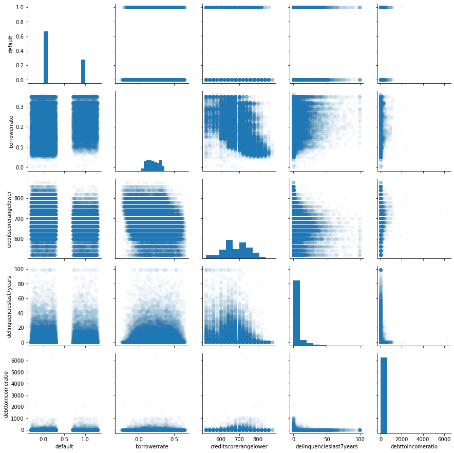

```python
g = sb.PairGrid(data = loan_analysis, vars = ['default', 'borrowerrate', 'creditscorerangelower', \
                                              'delinquencieslast7years', 'debttoincomeratio'])
g.map_diag(plt.hist)
g.map_offdiag(sb.regplot, truncate = False, x_jitter = 0.3, scatter_kws = {'alpha': 1/40}, fit_reg = False);
```

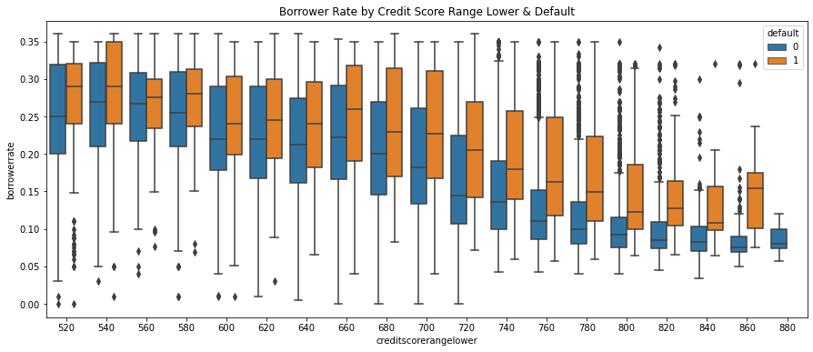

```python
plt.figure(figsize = (15, 6))
sb.boxplot(data = loan_analysis, x = 'creditscorerangelower', y = 'borrowerrate', hue = 'default');
plt.title('Borrower Rate by Credit Score Range Lower & Default');
```

> For each credit score, we see that the borrower rate for default group are more likely to be higher.

> From the bivariate analysis, we know that group Not Employed and \$0 have much higher Debt to Income Ratio on average. And group \\$1 - \$24,999 has some pretty high outliers too. I will seperate these group in the analysis.

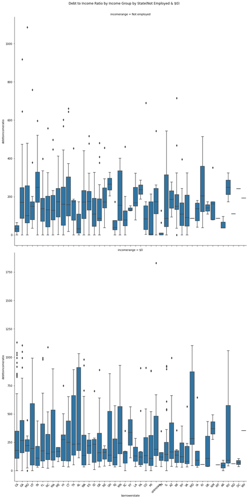

```python
# Group Not Employed and $0
no_salary = loan_analysis.loc[loan_analysis['incomerange'].isin(['$0', 'Not employed']), ['incomerange', 'borrowerstate', 'debttoincomeratio']]
no_salary['incomerange'] = no_salary['incomerange'].astype(str)
g = sb.FacetGrid(data = no_salary, col = 'incomerange', col_wrap = 1, size = 13, sharey = False, margin_titles = True);
g.map(sb.boxplot, 'borrowerstate', 'debttoincomeratio');
plt.xticks(rotation = 45);
g.fig.subplots_adjust(top = 0.95);
g.fig.suptitle('Debt to Income Ratio by Income Group by State(Not Employed & $0)');
```

[figure not shown]

```python
# Group excluding Not Employed and $0
salary = loan_analysis.loc[~loan_analysis['incomerange'].isin(['$0', 'Not employed']), ['incomerange', 'borrowerstate', 'debttoincomeratio']]
salary['incomerange'] = salary['incomerange'].astype(str)
g = sb.FacetGrid(data = salary, col = 'incomerange', col_wrap = 1, size = 13);
g.map(sb.boxplot, 'borrowerstate', 'debttoincomeratio');
plt.ylim(0, 5);
plt.xticks(rotation = 45);
g.fig.subplots_adjust(top = 0.97);
g.fig.suptitle('Debt to Income Ratio by Income Group by State(With Income & Not Display)');
```

> Income group *Not Employed* and *\$0* have much higher debt to income ratio than other income groups in general. And group *Not Employed*, *\$0*, and *Not displayed* have much more varied debt to income rate in different states.

[figure not shown]

```python
g = sb.FacetGrid(data = loan_analysis, col = 'creditscorerangelower', col_wrap = 3);
g.map(sb.regplot, 'default', 'delinquencieslast7years', x_jitter = 0.1, scatter_kws = {'alpha': 1/5});
g.fig.subplots_adjust(top = 0.95);
g.fig.suptitle('Debt to Income Ratio by Default State by Credit Score Range Lower');
```

> There's not much difference between these two groups in terms of delinquencies in the last 7 years.

## Conclusion

After univariate, bivariate, and multivarite analysis, I have explored the correlation between **Default** and some variables of interest. I've found out that if I want to predict a loan's going to be default or not, I can start by using variables such as *borrower rate*, *income range*, *credit score*, *listing type*, *state*, and *debt to income ratio* in the model.

#### Reference:

https://pandas.pydata.org/pandas-docs/stable/reference/api/pandas.DataFrame.select_dtypes.html https://thispointer.com/python-pandas-how-to-display-full-dataframe-i-e-print-all-rows-columns-without-truncation/ https://www.dataquest.io/blog/tutorial-add-column-pandas-dataframe-based-on-if-else-condition/ https://stackoverflow.com/questions/21090316/plotting-pandas-dataframes-in-to-pie-charts-using-matplotlib https://stackoverflow.com/questions/61908745/error-astype-got-an-unexpected-keyword-argument-categories